# Welcome to Green Residency

Guest House Manual

## Welcome

Welcome to Green Residency. We are delighted to host you.

## Property Overview

**Type**2-bedroom apartment

**Bedrooms**2

**Bathrooms**2

**Maximum guests**4

## Arrival & Check-in

**Check-in:** 2 PM

**Access instructions:** Use the main gate keypad code sent on the day of arrival. Take the lift to the third floor; Flat 302 is the second door on the left.

## Wi-Fi

Network

**GreenGuest**

## Appliances

### Air conditioner

Use the white remote beside the bed. Set it to Cool mode and keep doors and windows closed.

### Washing machine

Use liquid detergent only. Select the Quick Wash cycle for small loads and leave the door ajar after use.

### Refrigerator

The refrigerator is always on. Please keep the freezer door fully closed.

### Microwave

Use microwave-safe containers only and never operate the microwave empty.

### TV

Press the Home button on the remote to open streaming apps. Please sign out of personal accounts before checkout.

### Water heater

Switch it on 10 minutes before use, then switch it off after bathing.

## House Rules

### Quiet hours

Quiet hours are from 10 PM to 7 AM. Please keep music, TV, and conversations low during this time.

### No smoking

Smoking and vaping are not permitted anywhere inside the property.

### No parties or events

Parties, events, and unregistered visitors are not permitted.

### Check-out policy

Please check out by 11 AM, switch off appliances, place keys on the entry table, and send the manager a short confirmation message.

### Maximum guests

4 guests may stay at the property.

## Local Recommendations

### Restaurant · Nagarjuna

Classic Andhra meals and biryani. 550 m

### Grocery · Nature's Basket

Convenient groceries and essentials. 350 m

### Pharmacy · Apollo Pharmacy

Late-evening pharmacy and basic health supplies. 400 m

### Metro · Indiranagar Metro Station

Fast connection to MG Road and central Bangalore. 700 m

### Attraction · Cubbon Park

A peaceful urban park, ideal for a morning walk. 5 km

## Emergency Information

**Emergency number:** 112

**Property manager:** Ananya Rao: +91 98765 43210

**Hospital:** Manipal Hospital, Old Airport Road: +91 80 2502 4444

For an immediate emergency call 112 first, then contact the property manager when it is safe to do so.

## Check-out

Please check out by 11 AM, switch off appliances, place keys on the entry table, and send the manager a short confirmation message.

## Photos

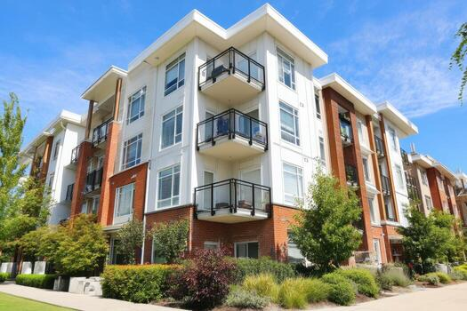

Green Residency exterior

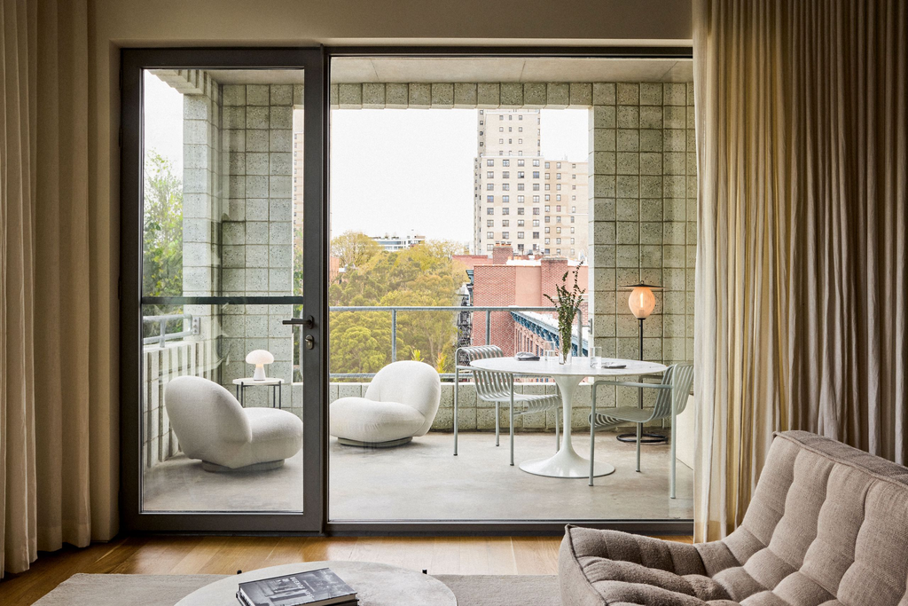

Bright living room

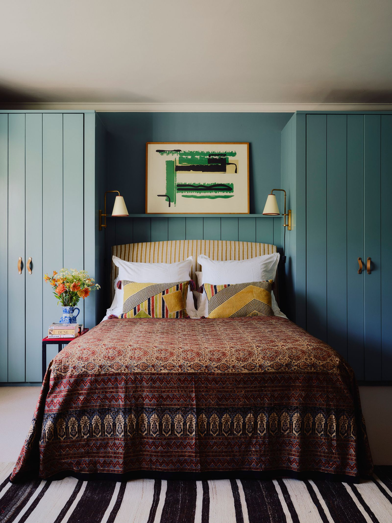

Primary bedroom

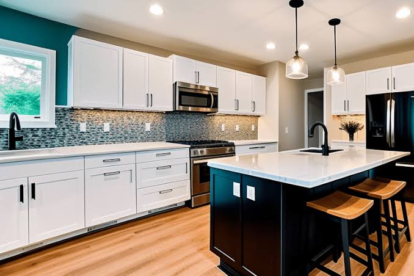

Fully equipped kitchen

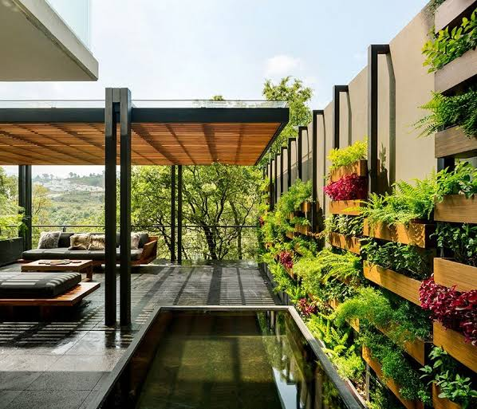

## Location & Map

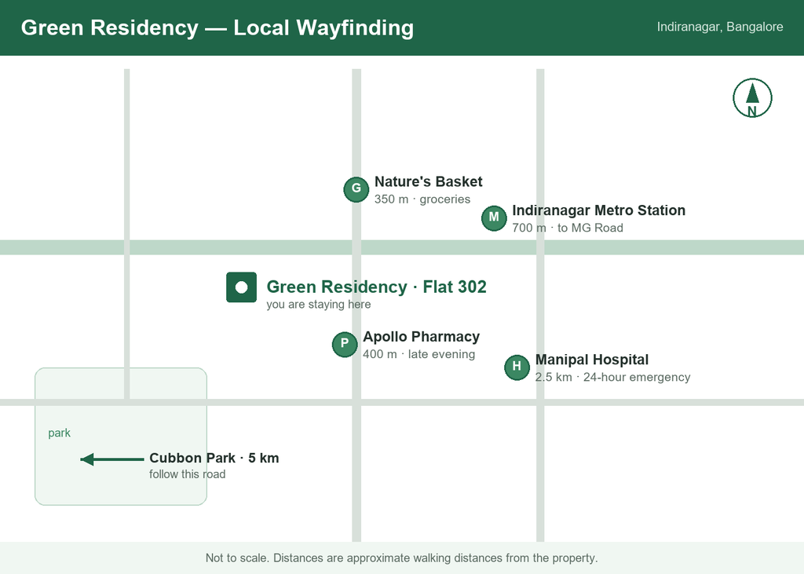

Local wayfinding map